# Activity 1

Joe Margolis

9/2/2021

# 3.1

Overall my favorite food is definitely sushi, but that is a broad food group. Some of my favorite types of sushi rolls include…

- California Roll
  - Spicy California
  - Normal California
- Unagi Roll
- Rainbow Roll
- Spicy Tuna Roll
- Alaska Roll

My favorite place to get sushi is a restaraunt called Midori in my hometown Chicago, Illinois. At Midori every meal comes with a starting of complimentary appetizers that are delicious. The order of appetizers goes…

1. Green tea
2. Miso Soup
3. Green Beans with their spicy sauce
4. Mushrooms with their spicy sauce
5. Ginger salad

Of course nothing beats when you see this boat of all the best sushi rolls Chicago has to offer on the way to your table…

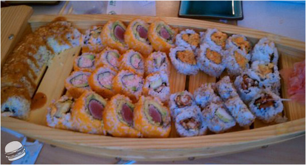

# 3.2

```r
install.packages('fivethirtyeightdata', repos = 'https://fivethirtyeightdata.github.io/drat/', type = 'source')
```

## 3.2.A.)

```r
library(fivethirtyeightdata)
comic <- data(comic_characters)
```

## 3.2.B.)

```r
head(comic_characters)
```

```
##   publisher page_id                        name
## 1        DC    1422        Batman (Bruce Wayne)
## 2        DC   23387       Superman (Clark Kent)
## 3        DC    1458  Green Lantern (Hal Jordan)
## 4        DC    1659    James Gordon (New Earth)
## 5        DC    1576 Richard Grayson (New Earth)
## 6        DC    1448 Wonder Woman (Diana Prince)
##                                 urlslug              id           align
## 1        \\/wiki\\/Batman_(Bruce_Wayne) Secret Identity Good Characters
## 2       \\/wiki\\/Superman_(Clark_Kent) Secret Identity Good Characters
## 3  \\/wiki\\/Green_Lantern_(Hal_Jordan) Secret Identity Good Characters
## 4    \\/wiki\\/James_Gordon_(New_Earth) Public Identity Good Characters
## 5 \\/wiki\\/Richard_Grayson_(New_Earth) Secret Identity Good Characters
## 6 \\/wiki\\/Wonder_Woman_(Diana_Prince) Public Identity Good Characters
##          eye       hair               sex  gsm             alive appearances
## 1  Blue Eyes Black Hair   Male Characters <NA> Living Characters        3093
## 2  Blue Eyes Black Hair   Male Characters <NA> Living Characters        2496
## 3 Brown Eyes Brown Hair   Male Characters <NA> Living Characters        1565
## 4 Brown Eyes White Hair   Male Characters <NA> Living Characters        1316
## 5  Blue Eyes Black Hair   Male Characters <NA> Living Characters        1237
## 6  Blue Eyes Black Hair Female Characters <NA> Living Characters        1231
##   first_appearance    month year       date
## 1        1939, May      May 1939 1939-05-01
## 2    1986, October  October 1986 1986-10-01
## 3    1959, October  October 1959 1959-10-01
## 4   1987, February February 1987 1987-02-01
## 5      1940, April    April 1940 1940-04-01
## 6   1941, December December 1941 1941-12-01
```

## 3.2.C.)

```r
head(comic_characters, 12)
```

```
##    publisher page_id                           name
## 1         DC    1422           Batman (Bruce Wayne)
## 2         DC   23387          Superman (Clark Kent)
## 3         DC    1458     Green Lantern (Hal Jordan)
## 4         DC    1659       James Gordon (New Earth)
## 5         DC    1576    Richard Grayson (New Earth)
## 6         DC    1448    Wonder Woman (Diana Prince)
## 7         DC    1486         Aquaman (Arthur Curry)
## 8         DC    1451      Timothy Drake (New Earth)
## 9         DC   71760 Dinah Laurel Lance (New Earth)
## 10        DC    1380            Flash (Barry Allen)
## 11        DC  403631                     GenderTest
## 12        DC    1459         Alan Scott (New Earth)
##                                     urlslug              id           align
## 1            \\/wiki\\/Batman_(Bruce_Wayne) Secret Identity Good Characters
```

[output cut: 37 more lines]

## 3.2.D.)

```r
names(comic_characters)
```

```
##  [1] "publisher"        "page_id"          "name"             "urlslug"
##  [5] "id"               "align"            "eye"              "hair"
##  [9] "sex"              "gsm"              "alive"            "appearances"
## [13] "first_appearance" "month"            "year"             "date"
```

## 3.2.E.)

```r
class(comic_characters$date)
```

```
## [1] "Date"
```

The date variable in the comic_characters dataset is classified as a date.

## 3.2.F.)

```r
na.omit(comic_characters$gsm)
```

[output not shown]

[output cut: 1967 more lines]